# Yfirlit yfir helstu föll og pakka

# Notbook og Rmarkdown

Hægt að geyma texta og kóða á sama stað Hægt að blanda saman kóða úr mismunandi forritunarmálum.

# Þetta er titill

## Þetta undirtitill

… Þannig að það er hægt að gera skýrslu.

- Lista
- má
- gera
- svona
1. það
2. er
3. líka
4. hægt að gera númeraða lista

*Þetta* er skáletrað, **Þetta** er feitletrað og *Þetta* er bæði.

Hægt er að nota latex stærðfræði notation með því að setja dollara merki fyrir framan og aftan, eins og $\hat{\beta}=(\mathbf{x}^T\mathbf{x})^{-1}\mathbf{x}^T\mathbf{y}$ :)

Einnig hægt að setja inn chunk svona:

Mathematical displays are marked off with `\[` and `\]`, as in
$$e^{i \pi} = -1$$

Skýrslan er keyrð með *ctrl+shift+k*

## Kóði

hægt að setja inn kóða “chunk” með því að setja “```” fremst og aftast.

*ctr+alt+i* gerir það sjálfkrafa

Hægt er að keyra allan chunkinn með *ctr+shift+enter* eða ýta á ‘play’ takkann sem birtist.

```r
# Þetta er komment. Hægt er að kommenta kóða með því að ýta á ctr+shift+c

5 + 5
```

```
## [1] 10
```

Yfirleitt er fyrsti búturinn *setup* bútur þar sem við hlöðum inn pökkum sem við ætlum að nota og setjum fram stillingar:

```r
knitr::opts_chunk$set(
    echo = TRUE,                         # Á að prenta kóðan? Hef þetta oft FALSE.
    fig.width = 16 / 2.54,               # Breidd á myndum í tommum, hægt að breyta í hverjum chunk
    fig.asp = 8 / 16,
    message = FALSE,                     # Á að Sýna skilaboð í html skjalinu?
    warning = FALSE,                     # Á að sýna warnings
    include = TRUE,
    dpi = 600,
    dev = "png",
    dev.args=list(bg="white"),
    out.width = "100%"
)

# Fer yfir pakkanna seinna!
library(DBI)
library(tidyverse)
library(sf)
library(seasonal)
library(tsibble)
library(lubridate)
library(here)
library(dbplyr)
# Theme og hjálparföll fyrir myndir
source("https://github.com/karsfri/ILS/raw/master/theme_hms.R")
```

Sjá helstu skipanir undir *help/markdown quick reference*

Sjá ýtarlegri samantekt um Rmarkdown:

- https://bookdown.org/yihui/rmarkdown/
- https://www.stat.cmu.edu/~cshalizi/rmarkdown/

# R-project

Eina sem það gerir er að halda utan um R skjöl og Rmd skjöl í sömu möppu og notar staðsetningu *.Rproj*

## pakkar

Flestir pakkar eru á *cran*. Þá er hægt að ná í svona:

```r
# Ég kommenta út fallið svo ég keyri það ekki óvart
# install.packages("here")
```

# Sækja gögn

## Slóðir

Í windows virkar bara “/” eða “\” en ekki "" því það er escape character.

```r
slod <- "G:/Hagdeild/Manadarskyrsla_Hagdeildar/2019/November/Byggingamarkadur"      # virkar
slod <- "G:\\Hagdeild\\Manadarskyrsla_Hagdeildar\\2019\\November\\Byggingamarkadur" # virkar
```

Í linux og apple er hins vegar yfirleitt notað "". Því er hægt að nota fallið *here* úr *here* pakkanum til þess að notast við slóð sem virkar á öllum stýrikerfum:

```r
slod <- here::here("G", "Hagdeild", "Manadarskyrsla_Hagdeildar", "2019", "November", "Byggingamarkadur")
```

## Úr grunninum

Hægt er að blanda saman kóða úr mismunandi forritum. Fyrst þarf að búa til tengingu við R.

```r
con <- dbConnect(
  drv = odbc::odbc(),
  dsn = "HgrDev",
  timeout = 10,
  # database = "HgrProd",
  encoding = "WINDOWS-1252"
  )
```

Svo er hægt að setja inn *SQL* chunk og vista outputið sem breytu með nafni sem er skilgreint í haus sem “output.var”

```sql
SELECT [Dim_Timi_Utgefid]
      ,[Dim_Timi_Thinglyst]
      ,[Dim_Fasteignir]
      ,[Faerslunumer]
      ,[Kaupverd]
      ,[Kaupverd_nuvirdi]
      ,[FjoldiFasteigna]
      ,[FjoldiMatseininga]
      ,[OnothaefurSamningur]
      ,[AuglystDags]
      ,[AuglystSoluverd]
      ,[SeltYfirAuglystuSoluverdi]
      ,[SeltAAuglystuSoluverdi]
      ,[SeltUndirAuglystuSoluverdi]
      ,[Postnumer]
      ,[Landshlutaflokkun]
      ,[Landshluti]
      ,[Lengdargrada]
      ,[Breiddargrada]
      ,[Ar]
      ,[ByggingarAr]
      ,[ByggingarstigByggingarfulltrua]
      ,[Fastanumer]
      ,[Matsstig]
  FROM [HgrDwh].[dwh].[Fact_Kaupsamningar_Stakar] s
    INNER JOIN [HgrDwh].[dwh].[Dim_Fasteignir] f
    ON  s.Dim_Fasteignir = f.Dim_Fasteignir_sk
    INNER JOIN [HgrDwh].[dwh].[Dim_Timi] t
    ON s.Dim_Timi_Utgefid = dim_timi_sk
WHERE t.Ar > 2012
AND ErIbud = 1
```

Þá er ég kominn með breytuna *leiga* sem ég get notað í R:

```r
leiga
```

| Dim_Timi_Utgefid | Dim_Timi_Thinglyst | Dim_Fasteignir | Faerslunumer | Kaupverd | Kaupverd_nuvirdi | FjoldiFasteigna | FjoldiMatseininga | OnothaefurSamningur | AuglystDags | AuglystSoluverd | SeltYfirAuglystuSoluverdi | SeltAAuglystuSoluverdi | SeltUndirAuglystuSoluverdi | Postnumer | Landshlutaflokkun | Landshluti | Lengdargrada | Breiddargrada | Ar | ByggingarAr | ByggingarstigByggingarfulltrua | Fastanumer | Matsstig |
| --- | --- | --- | --- | --- | --- | --- | --- | --- | --- | --- | --- | --- | --- | --- | --- | --- | --- | --- | --- | --- | --- | --- | --- |

## tenging við grunn

Geyma

# Meðhöndlun gagna

Þrjár “bragðtegundir”; base R, tidyverse og data.table. Hér er farið yfir *tidyverse*.

## tsibble

Yfirleitt erum við að vinna með töflur með klassa “data.frame”.

```r
class(mtcars)
```

```
## [1] "data.frame"
```

Tveir stórir gallar við þann hluti af þeim klassa er að þeir prentast mjög kjánalega út (á bara við þegar ekki er verið að vinna í markdown) og ef aðeins er valin einn dálkur breytist hann sjálfkrafa í vector sem hefur aðra eiginleika. Því er hætt við að fá leiðinlegar villur sem erfitt er að finna.

```r
mtcars[ ,1] # allar raðir, fyrsti dálkur
```

```
##  [1] 21.0 21.0 22.8 21.4 18.7 18.1 14.3 24.4 22.8 19.2 17.8 16.4 17.3 15.2 10.4
## [16] 10.4 14.7 32.4 30.4 33.9 21.5 15.5 15.2 13.3 19.2 27.3 26.0 30.4 15.8 19.7
## [31] 15.0 21.4
```

```r
# mtcars[ , 1, drop = FALSE] kemur í veg fyrir umbreytingu, en er auðvelt að gleyma.
```

```r
mtcars <- as_tibble(mtcars)
class(mtcars)
```

```
## [1] "tbl_df"     "tbl"        "data.frame"
```

```r
mtcars[ ,1]
```

| mpg |
| --- |
| 21.0 |
| 21.0 |
| 22.8 |
| 21.4 |
| 18.7 |
| 18.1 |
| 14.3 |
| 24.4 |
| 22.8 |
| 19.2 |

[output cut: 22 more lines]

## magrittr

Pípur eru dálítið umdeildar en geta verið mjög þægilegar!

Í stað þess að skrifa $f(x, y)$ er hægt að skrifa $x\text{ %>% }f(y)$.

Sérstaklega hjálplegt því gögnin eru oft fyrsta argument-ið.

Hægt að nota *ctrl+shift+M* til að setja inn pípu sjálfkrafa

```r
# einhverjar tölur
x <- c(0.109, 0.359, 0.63, 0.996, 0.515, 0.142, 0.017, 0.829, 0.907)

# Hefðbundna leiðin fyrir útreikninga:
round(exp(diff(log(x))), 1)
```

```
## [1]  3.3  1.8  1.6  0.5  0.3  0.1 48.8  1.1
```

```r
# Með endurteknu assignment er það læsilegra

x2 <- log(x)
x2 <- diff(x2)
x2 <- exp(x2)
x2 <- round(x2, 1)
```

```r
# Með pípu er það þægilegra:
x %>%
  log() %>%
  diff() %>%
  exp() %>%
  round(1)
```

```
## [1]  3.3  1.8  1.6  0.5  0.3  0.1 48.8  1.1
```

## tidyr

Hugmyndin á bakvið *tidyverse* pakkanna er að öll gögn, bæði intak og úttak, séu *tidy*, sem þýðir í raun aðeins að hver dálkur hefur eina, og aðeins eina breytu (Þótt að hvað teljist breyta getur verið óljóst og farið aðeins eftir samhengi). Annars staðar er þetta kallað *long* formatt. Í raun sama formatt á gögnunum eins og excel krefst til þess að hægt sé að nota pivot-töflur með góðu móti.

Sjá meira um tidy gögn [hér](https://vita.had.co.nz/papers/tidy-data.pdf)

Þetta form er þægilegt fyrir gagnavinnslu en óþægilegt til þess að lesa úr og þess vegna er gott að geta farið á milli!

Tidyr pakkinn inniheldur nokkur föll sem hjálpa að ymbreyta *untidy* gögnum í *tidy* gögn. Það er líklega lítil þörf á honum þegar notast er við gögn úr grunninum en getur verið mjög hjálplegur við önnur gögn, t.d. úr excel.

### gather (pivot_longer)

Fölling *gather* og *pivot_longer* eru bæði til þess fallin að fara úr *wide* formatti yfir í *long*. *Gather* er fljótlegra en *pivot_longer* er sveigjanlegra og sumum finnst það læsilegra.

Hérna er gagnasett frá hagstofunni þar sem hluti af dálkheitum, þ.e. landssvæði, eru í raun breytur.

```r
pop <- read_csv(
  "https://px.hagstofa.is:443/pxis/sq/16fe80b6-c886-4d5d-b2e4-17240fd28f2f",
  locale = locale(
    encoding = "WINDOWS-1252",
    decimal_mark = ",",
    grouping_mark = "."
  )
)

pop
```

| Aldur | Ár | Kyn | Alls | Höfuðborgarsvæði | Suðurnes | Vesturland | Vestfirðir | Norðurland vestra | Norðurland eystra | Austurland | Suðurland |
| --- | --- | --- | --- | --- | --- | --- | --- | --- | --- | --- | --- |
| Alls | 1998 | Karlar | 136444 | 81077 | 8075 | 7144 | 4459 | 4992 | 13511 | 6510 | 10676 |
| Alls | 1998 | Konur | 135937 | 83529 | 7640 | 6780 | 4197 | 4793 | 13121 | 6064 | 9813 |
| Alls | 1999 | Karlar | 138086 | 82976 | 8116 | 7151 | 4400 | 4922 | 13403 | 6373 | 10745 |
| Alls | 1999 | Konur | 137626 | 85368 | 7743 | 6799 | 4200 | 4667 | 13089 | 5925 | 9835 |
| Alls | 2000 | Karlar | 139665 | 84653 | 8220 | 7233 | 4269 | 4831 | 13340 | 6264 | 10855 |
| Alls | 2000 | Konur | 139384 | 87139 | 7886 | 6829 | 4041 | 4605 | 13036 | 5848 | 10000 |
| Alls | 2001 | Karlar | 141870 | 86497 | 8437 | 7325 | 4180 | 4836 | 13420 | 6186 | 10989 |
| Alls | 2001 | Konur | 141491 | 88930 | 8094 | 6953 | 3972 | 4587 | 13075 | 5748 | 10132 |
| Alls | 2002 | Karlar | 143450 | 87924 | 8565 | 7445 | 4106 | 4766 | 13457 | 6116 | 11071 |
| Alls | 2002 | Konur | 143125 | 90377 | 8165 | 7024 | 3914 | 4535 | 13174 | 5685 | 10251 |

[output cut: 34 more lines]

Hér er hægt að nota *gather* fallið til þess að safna saman dálkum. Fyrsta argumentið (fyrir utan gögnin sem eru fyrir framan í pípunni) er nafnið sem dálkurinn fær sem geymir nöfnin þá þeim dálkum sem er safnað saman. Annað argumentið erð nafn á dálkinum sem geymir gögnin. Svo koma nöfn á dálkunum sem á að safna saman. Hér má nota ýmiss hjálparföll sem verður vikið að síðar.

```r
pop_tidy <- pop %>%
  gather(
    key = "Landssvæði",
    value = "Fólksfjöldi",
    Höfuðborgarsvæði:`Suðurland` # Tilgreina hvaða dálkum á að safna saman
  )

pop_tidy
```

| Aldur | Ár | Kyn | Alls | Landssvæði | Fólksfjöldi |
| --- | --- | --- | --- | --- | --- |
| Alls | 1998 | Karlar | 136444 | Höfuðborgarsvæði | 81077 |
| Alls | 1998 | Konur | 135937 | Höfuðborgarsvæði | 83529 |
| Alls | 1999 | Karlar | 138086 | Höfuðborgarsvæði | 82976 |
| Alls | 1999 | Konur | 137626 | Höfuðborgarsvæði | 85368 |
| Alls | 2000 | Karlar | 139665 | Höfuðborgarsvæði | 84653 |
| Alls | 2000 | Konur | 139384 | Höfuðborgarsvæði | 87139 |
| Alls | 2001 | Karlar | 141870 | Höfuðborgarsvæði | 86497 |
| Alls | 2001 | Konur | 141491 | Höfuðborgarsvæði | 88930 |
| Alls | 2002 | Karlar | 143450 | Höfuðborgarsvæði | 87924 |
| Alls | 2002 | Konur | 143125 | Höfuðborgarsvæði | 90377 |

[output cut: 342 more lines]

```r
# Athugið, vildi ekki taka "Alls" með!
```

Önnur leið, oft fljótlegri er að tilgreina hvaða breytur á ekki að safna saman:

```r
pop %>%
  gather(
    key = "Landssvæði",
    value = "Fólksfjöldi",
    - Aldur,
    - Ár,
    - Kyn,
    - Alls
  )
```

| Aldur | Ár | Kyn | Alls | Landssvæði | Fólksfjöldi |
| --- | --- | --- | --- | --- | --- |
| Alls | 1998 | Karlar | 136444 | Höfuðborgarsvæði | 81077 |
| Alls | 1998 | Konur | 135937 | Höfuðborgarsvæði | 83529 |
| Alls | 1999 | Karlar | 138086 | Höfuðborgarsvæði | 82976 |
| Alls | 1999 | Konur | 137626 | Höfuðborgarsvæði | 85368 |
| Alls | 2000 | Karlar | 139665 | Höfuðborgarsvæði | 84653 |
| Alls | 2000 | Konur | 139384 | Höfuðborgarsvæði | 87139 |
| Alls | 2001 | Karlar | 141870 | Höfuðborgarsvæði | 86497 |
| Alls | 2001 | Konur | 141491 | Höfuðborgarsvæði | 88930 |
| Alls | 2002 | Karlar | 143450 | Höfuðborgarsvæði | 87924 |
| Alls | 2002 | Konur | 143125 | Höfuðborgarsvæði | 90377 |

[output cut: 342 more lines]

```r
pop %>%
  pivot_longer(
    cols = Höfuðborgarsvæði:`Suðurland`,
    names_to = "Landssvæði",
    values_to = "Fólksfjöldi"
  )
```

| Aldur | Ár | Kyn | Alls | Landssvæði | Fólksfjöldi |
| --- | --- | --- | --- | --- | --- |
| Alls | 1998 | Karlar | 136444 | Höfuðborgarsvæði | 81077 |
| Alls | 1998 | Karlar | 136444 | Suðurnes | 8075 |
| Alls | 1998 | Karlar | 136444 | Vesturland | 7144 |
| Alls | 1998 | Karlar | 136444 | Vestfirðir | 4459 |
| Alls | 1998 | Karlar | 136444 | Norðurland vestra | 4992 |
| Alls | 1998 | Karlar | 136444 | Norðurland eystra | 13511 |
| Alls | 1998 | Karlar | 136444 | Austurland | 6510 |
| Alls | 1998 | Karlar | 136444 | Suðurland | 10676 |
| Alls | 1998 | Konur | 135937 | Höfuðborgarsvæði | 83529 |
| Alls | 1998 | Konur | 135937 | Suðurnes | 7640 |

[output cut: 342 more lines]

### spread og pivot_wider

Föllin *spread* og *pivot_wider* eru andhverfur við *gather* og *pivot_longer*. Mun sjaldnar notað, en oft gott áður en gögn eru skrifuð út í csv eða excel skjal ef að helsti tilgangur þeirra er að skoða þau en ekki vinna áfram með þau.

```r
pop_tidy %>%
  select(-Alls) %>% # Tók út "Alls" til þess að fá Karla og Konur í sömu röðum.
  spread(Kyn, Fólksfjöldi)
```

| Aldur | Ár | Landssvæði | Karlar | Konur |
| --- | --- | --- | --- | --- |
| Alls | 1998 | Austurland | 6510 | 6064 |
| Alls | 1998 | Höfuðborgarsvæði | 81077 | 83529 |
| Alls | 1998 | Norðurland eystra | 13511 | 13121 |
| Alls | 1998 | Norðurland vestra | 4992 | 4793 |
| Alls | 1998 | Suðurland | 10676 | 9813 |
| Alls | 1998 | Suðurnes | 8075 | 7640 |
| Alls | 1998 | Vestfirðir | 4459 | 4197 |
| Alls | 1998 | Vesturland | 7144 | 6780 |
| Alls | 1999 | Austurland | 6373 | 5925 |
| Alls | 1999 | Höfuðborgarsvæði | 82976 | 85368 |

[output cut: 166 more lines]

```r
pop_tidy %>%
  select(-Alls) %>%
  pivot_wider(
    names_from = Kyn,
    values_from = Fólksfjöldi
  )
```

| Aldur | Ár | Landssvæði | Karlar | Konur |
| --- | --- | --- | --- | --- |
| Alls | 1998 | Höfuðborgarsvæði | 81077 | 83529 |
| Alls | 1999 | Höfuðborgarsvæði | 82976 | 85368 |
| Alls | 2000 | Höfuðborgarsvæði | 84653 | 87139 |
| Alls | 2001 | Höfuðborgarsvæði | 86497 | 88930 |
| Alls | 2002 | Höfuðborgarsvæði | 87924 | 90377 |
| Alls | 2003 | Höfuðborgarsvæði | 88719 | 91273 |
| Alls | 2004 | Höfuðborgarsvæði | 89748 | 92169 |
| Alls | 2005 | Höfuðborgarsvæði | 90963 | 93281 |
| Alls | 2006 | Höfuðborgarsvæði | 92807 | 94619 |
| Alls | 2007 | Höfuðborgarsvæði | 95591 | 96328 |

[output cut: 166 more lines]

Sjá flóknari notkun [hér](https://tidyr.tidyverse.org/articles/pivot.html).

### SQL eftirhermur

Hægt er að tengja saman gögn úr mismunandi *df* með föllunum left_join, right_join, inner_join, og full_join. Ef að töflurnar hafa sömu nöfn **og** sama classa (t.d. factor, charachter, logical, int eða double).

Föllinn semi_join má nota til þess að sjá hvaða raðir verða “join-aðar” og anti_join má nota til þess að sjá hvaða raðir verða ekki “join-aðar”.

Ef töflurnar hafa sömu dálkaheiti má sameina þær með bind_rows (fara varlega!) og ef þær eru með jafnmörgum röðum má nota bind_columns.

Mengja virkjarnir intersect, setdiff og union má beita á raðir ef að dálkar eru þeir sömu.

### Önnur hjálpleg föll

- *seperate* Til þess að splitta einum dálki í tvo eða fleiri dálka
- *extract* Sama og *seperate* nema hendir öllum dálkum nema fyrsta
- *unite* Sameinar tvo eða fleiri dálka í einn
- *complete* Bætir við röðum sem vantar; breytir implicit *NA* í explicit *NA*
- *fill* fyllir uppí *NA* miðað við gildin á undan eða eftir (Getur verið algjörlega nauðsynlegt að nota með group_by til þess að ekki séu notuð óviðeigandi gildi - sjá síðar)
- *drop_na* henda út röðum með *NA* gildi í ákveðnum dálkum (eða einhverjum dálkum)
- *replace_na* Sá sem giskar rétt á þetta fær ís að launum.

## dplyr

Samansafn af fimm sögnum, ásamt hjálparföllum, sem auðvelda alla meðhöndlun gagna.

- mutate
- select
- filter
- summarize
- arrange

*dplyr* pakkinn inniheldur einnig *group_by* fallið sem gerir það að verkum að aðrar aðgerðir séu skipt í hópa eftir gildum á viðkomandi breytum. Sést betur með notkun.

```r
pop_tidy %>%
  group_by(Landssvæði) %>%
  class
```

```
## [1] "grouped_df" "tbl_df"     "tbl"        "data.frame"
```

*mutate* fallið er notað til þess að framkvæma útreikninga á dálkum. Athugið, að ólíkt *base-R* er ekki gert ráð fyrir gæsalöppum á dálkheitum. Það getur gert lífið aðeins flóknara þegar verið er að búa til föll, en það er dýflisa sem má bíða betri tíma! (hint: litlum sálum ráðlagt að googla ekki ‘rlang’ rétt fyrir svefninn).

```r
pop_tidy %>%
  group_by(Landssvæði, Kyn) %>% # Hér er mikilvægt að hópa bæði eftir kyni og Landssvæði, annars væri niðurstaðan della!
  mutate(
    Fjölgun = Fólksfjöldi / lag(Fólksfjöldi) - 1,
    Hlutfall = Fólksfjöldi / Alls,
    `Hlutfallsleg fjölgun` = Fjölgun / Fólksfjöldi # Get nýtt það sem er reiknað að ofan innan sama falls!
  )
```

| Aldur | Ár | Kyn | Alls | Landssvæði | Fólksfjöldi | Fjölgun | Hlutfall | Hlutfallsleg fjölgun |
| --- | --- | --- | --- | --- | --- | --- | --- | --- |
| Alls | 1998 | Karlar | 136444 | Höfuðborgarsvæði | 81077 | NA | 0.59421448 | NA |
| Alls | 1998 | Konur | 135937 | Höfuðborgarsvæði | 83529 | NA | 0.61446847 | NA |
| Alls | 1999 | Karlar | 138086 | Höfuðborgarsvæði | 82976 | 0.0234221789 | 0.60090089 | 2.822765e-07 |
| Alls | 1999 | Konur | 137626 | Höfuðborgarsvæði | 85368 | 0.0220163057 | 0.62028977 | 2.578988e-07 |
| Alls | 2000 | Karlar | 139665 | Höfuðborgarsvæði | 84653 | 0.0202106633 | 0.60611463 | 2.387472e-07 |
| Alls | 2000 | Konur | 139384 | Höfuðborgarsvæði | 87139 | 0.0207454784 | 0.62517219 | 2.380734e-07 |
| Alls | 2001 | Karlar | 141870 | Höfuðborgarsvæði | 86497 | 0.0217830437 | 0.60969197 | 2.518358e-07 |
| Alls | 2001 | Konur | 141491 | Höfuðborgarsvæði | 88930 | 0.0205533688 | 0.62852054 | 2.311185e-07 |
| Alls | 2002 | Karlar | 143450 | Höfuðborgarsvæði | 87924 | 0.0164976820 | 0.61292436 | 1.876357e-07 |
| Alls | 2002 | Konur | 143125 | Höfuðborgarsvæði | 90377 | 0.0162712246 | 0.63145502 | 1.800372e-07 |

[output cut: 342 more lines]

*mutate* virkar aðeins ef að úttakið er jafn stórt og fjöldi raða!

*select* fallið er nýtt til þess að velja dálka

```r
pop_tidy %>%
  select(Fólksfjöldi) # Frekar gagnslaust í þessu samhengi
```

| Fólksfjöldi |
| --- |
| 81077 |
| 83529 |
| 82976 |
| 85368 |
| 84653 |
| 87139 |
| 86497 |
| 88930 |
| 87924 |
| 90377 |

[output cut: 342 more lines]

Einnig hægt að nota til þess að henda út dálkum:

```r
pop_tidy %>%
  select(-Alls)
```

| Aldur | Ár | Kyn | Landssvæði | Fólksfjöldi |
| --- | --- | --- | --- | --- |
| Alls | 1998 | Karlar | Höfuðborgarsvæði | 81077 |
| Alls | 1998 | Konur | Höfuðborgarsvæði | 83529 |
| Alls | 1999 | Karlar | Höfuðborgarsvæði | 82976 |
| Alls | 1999 | Konur | Höfuðborgarsvæði | 85368 |
| Alls | 2000 | Karlar | Höfuðborgarsvæði | 84653 |
| Alls | 2000 | Konur | Höfuðborgarsvæði | 87139 |
| Alls | 2001 | Karlar | Höfuðborgarsvæði | 86497 |
| Alls | 2001 | Konur | Höfuðborgarsvæði | 88930 |
| Alls | 2002 | Karlar | Höfuðborgarsvæði | 87924 |
| Alls | 2002 | Konur | Höfuðborgarsvæði | 90377 |

[output cut: 342 more lines]

*filter* er notað til þess að velja raðir út frá skilyrðum:

```r
pop_tidy %>%
  group_by(Landssvæði, Kyn) %>% # Hér er mikilvægt að hópa bæði eftir kyni og Landssvæði, annars væri niðurstaðan della!
  mutate(
    Fjölgun = Fólksfjöldi / lag(Fólksfjöldi) - 1,
    Hlutfall = Fólksfjöldi / Alls,
    `Hlutfallsleg fjölgun` = Fjölgun / Fólksfjöldi # Get nýtt það sem er reiknað að ofan innan sama falls!
  ) %>%
  filter(
    !is.na(Fjölgun),
    Kyn == "Karlar"
  )
```

| Aldur | Ár | Kyn | Alls | Landssvæði | Fólksfjöldi | Fjölgun | Hlutfall | Hlutfallsleg fjölgun |
| --- | --- | --- | --- | --- | --- | --- | --- | --- |
| Alls | 1999 | Karlar | 138086 | Höfuðborgarsvæði | 82976 | 0.0234221789 | 0.60090089 | 2.822765e-07 |
| Alls | 2000 | Karlar | 139665 | Höfuðborgarsvæði | 84653 | 0.0202106633 | 0.60611463 | 2.387472e-07 |
| Alls | 2001 | Karlar | 141870 | Höfuðborgarsvæði | 86497 | 0.0217830437 | 0.60969197 | 2.518358e-07 |
| Alls | 2002 | Karlar | 143450 | Höfuðborgarsvæði | 87924 | 0.0164976820 | 0.61292436 | 1.876357e-07 |
| Alls | 2003 | Karlar | 144287 | Höfuðborgarsvæði | 88719 | 0.0090418998 | 0.61487868 | 1.019162e-07 |
| Alls | 2004 | Karlar | 145401 | Höfuðborgarsvæði | 89748 | 0.0115984175 | 0.61724472 | 1.292332e-07 |
| Alls | 2005 | Karlar | 147170 | Höfuðborgarsvæði | 90963 | 0.0135379061 | 0.61808113 | 1.488287e-07 |
| Alls | 2006 | Karlar | 151202 | Höfuðborgarsvæði | 92807 | 0.0202719787 | 0.61379479 | 2.184316e-07 |
| Alls | 2007 | Karlar | 156576 | Höfuðborgarsvæði | 95591 | 0.0299977372 | 0.61050863 | 3.138134e-07 |
| Alls | 2008 | Karlar | 160896 | Höfuðborgarsvæði | 99499 | 0.0408825099 | 0.61840568 | 4.108836e-07 |

[output cut: 158 more lines]

Athugið að föll inní mutate ná utan um allan dálkin í viðkomkandi hóp eins og hann er skilgreindur miðað við *group_by* á meðan nafn á dálki vísar aðeins til viðkomandi raðar. Því má t.a.m. fá hlutfallslega skiptingu karla og kvenna með eftirfarandi hætti:

```r
pop_tidy %>%
  group_by(Ár, Landssvæði) %>%
  mutate(
    # Hér nær fyrra 'Fólksfjöldi' breytan til einnar raðar, en sú seinni til tveggja!
    Hlutfall = Fólksfjöldi / sum(Fólksfjöldi)
  )
```

| Aldur | Ár | Kyn | Alls | Landssvæði | Fólksfjöldi | Hlutfall |
| --- | --- | --- | --- | --- | --- | --- |
| Alls | 1998 | Karlar | 136444 | Höfuðborgarsvæði | 81077 | 0.4925519 |
| Alls | 1998 | Konur | 135937 | Höfuðborgarsvæði | 83529 | 0.5074481 |
| Alls | 1999 | Karlar | 138086 | Höfuðborgarsvæði | 82976 | 0.4928955 |
| Alls | 1999 | Konur | 137626 | Höfuðborgarsvæði | 85368 | 0.5071045 |
| Alls | 2000 | Karlar | 139665 | Höfuðborgarsvæði | 84653 | 0.4927645 |
| Alls | 2000 | Konur | 139384 | Höfuðborgarsvæði | 87139 | 0.5072355 |
| Alls | 2001 | Karlar | 141870 | Höfuðborgarsvæði | 86497 | 0.4930655 |
| Alls | 2001 | Konur | 141491 | Höfuðborgarsvæði | 88930 | 0.5069345 |
| Alls | 2002 | Karlar | 143450 | Höfuðborgarsvæði | 87924 | 0.4931212 |
| Alls | 2002 | Konur | 143125 | Höfuðborgarsvæði | 90377 | 0.5068788 |

[output cut: 342 more lines]

*summarize* er svipað og mutate, en þar er fjöldi raða jafn margar og fjöldi hópa:

```r
pop_tidy %>%
  filter(Ár == max(Ár)) %>%
  group_by(Ár, Landssvæði) %>%
  summarise(
    Fólksfjöldi = sum(Fólksfjöldi)
  )
```

| Ár | Landssvæði | Fólksfjöldi |
| --- | --- | --- |
| 2019 | Austurland | 13059 |
| 2019 | Höfuðborgarsvæði | 228231 |
| 2019 | Norðurland eystra | 30445 |
| 2019 | Norðurland vestra | 7227 |
| 2019 | Suðurland | 27346 |
| 2019 | Suðurnes | 27113 |
| 2019 | Vestfirðir | 7063 |
| 2019 | Vesturland | 16507 |

Sum föll virka bæði í summarize og mutate:

```r
pop_tidy %>%
  filter(Ár == max(Ár)) %>%
  group_by(Ár, Landssvæði) %>%
  mutate(
    Alls = sum(Fólksfjöldi),
    n = n() # n() er hjálparfall sem sýnir fjölda raða!
  )
```

| Aldur | Ár | Kyn | Alls | Landssvæði | Fólksfjöldi | n |
| --- | --- | --- | --- | --- | --- | --- |
| Alls | 2019 | Karlar | 228231 | Höfuðborgarsvæði | 115867 | 2 |
| Alls | 2019 | Konur | 228231 | Höfuðborgarsvæði | 112364 | 2 |
| Alls | 2019 | Karlar | 27113 | Suðurnes | 14524 | 2 |
| Alls | 2019 | Konur | 27113 | Suðurnes | 12589 | 2 |
| Alls | 2019 | Karlar | 16507 | Vesturland | 8612 | 2 |
| Alls | 2019 | Konur | 16507 | Vesturland | 7895 | 2 |
| Alls | 2019 | Karlar | 7063 | Vestfirðir | 3678 | 2 |
| Alls | 2019 | Konur | 7063 | Vestfirðir | 3385 | 2 |
| Alls | 2019 | Karlar | 7227 | Norðurland vestra | 3653 | 2 |
| Alls | 2019 | Konur | 7227 | Norðurland vestra | 3574 | 2 |

[output cut: 6 more lines]

*count* sýnir fjölda raða eftir tilgreindum breytum, en group_by breytum er alltaf bætt við!

```r
pop_tidy %>%
  count(Ár, Kyn)
```

| Ár | Kyn | n |
| --- | --- | --- |
| 1998 | Karlar | 8 |
| 1998 | Konur | 8 |
| 1999 | Karlar | 8 |
| 1999 | Konur | 8 |
| 2000 | Karlar | 8 |
| 2000 | Konur | 8 |
| 2001 | Karlar | 8 |
| 2001 | Konur | 8 |
| 2002 | Karlar | 8 |
| 2002 | Konur | 8 |

[output cut: 34 more lines]

```r
pop_tidy %>%
  group_by(Kyn) %>%
  count(Ár)
```

| Kyn | Ár | n |
| --- | --- | --- |
| Karlar | 1998 | 8 |
| Karlar | 1999 | 8 |
| Karlar | 2000 | 8 |
| Karlar | 2001 | 8 |
| Karlar | 2002 | 8 |
| Karlar | 2003 | 8 |
| Karlar | 2004 | 8 |
| Karlar | 2005 | 8 |
| Karlar | 2006 | 8 |
| Karlar | 2007 | 8 |

[output cut: 34 more lines]

*tally* er svipað en ekki er farið yfir það hér.

## lubridate

Lubridate pakkinn er aðalega notaður til þess að vinna með dagsetningar í R. Þegar gögn eru sótt í gegnum SQL inní R koma dagsetningar sem strengir.

```r
leiga %>%
  mutate(
    Dim_Timi_Utgefid = Dim_Timi_Utgefid %>% ymd(),
    Dim_Timi_Thinglyst = Dim_Timi_Thinglyst %>% ymd()
  )
```

| Dim_Timi_Utgefid | Dim_Timi_Thinglyst | Dim_Fasteignir | Faerslunumer | Kaupverd | Kaupverd_nuvirdi | FjoldiFasteigna | FjoldiMatseininga | OnothaefurSamningur | AuglystDags | AuglystSoluverd | SeltYfirAuglystuSoluverdi | SeltAAuglystuSoluverdi | SeltUndirAuglystuSoluverdi | Postnumer | Landshlutaflokkun | Landshluti | Lengdargrada | Breiddargrada | Ar | ByggingarAr | ByggingarstigByggingarfulltrua | Fastanumer | Matsstig |
| --- | --- | --- | --- | --- | --- | --- | --- | --- | --- | --- | --- | --- | --- | --- | --- | --- | --- | --- | --- | --- | --- | --- | --- |

Lubridate pakkinn virkar meira að segja nokkuð vel með íslenska staðla:

```r
vnv <- read_hagstofan("https://px.hagstofa.is:443/pxis/sq/7fa32768-b4c5-4499-a869-5b57c079d90a", delim = "\t")

vnv
```

| Ár | Mánuður | Vísitala neysluverðs Vísitala |
| --- | --- | --- |
| 1988 | Janúar | . |
| 1988 | Febrúar | . |
| 1988 | Mars | . |
| 1988 | Apríl | . |
| 1988 | Maí | 100.0 |
| 1988 | Júní | 103.4 |
| 1988 | Júlí | 107.0 |
| 1988 | Ágúst | 109.3 |
| 1988 | September | 110.0 |
| 1988 | Október | 110.4 |

[output cut: 374 more lines]

```r
vnv %>%
  mutate(
    time = ymd(paste(Ár, Mánuður, 01))
  )
```

| Ár | Mánuður | Vísitala neysluverðs Vísitala | time |
| --- | --- | --- | --- |
| 1988 | Janúar | . | 1988-01-01 |
| 1988 | Febrúar | . | 1988-02-01 |
| 1988 | Mars | . | 1988-03-01 |
| 1988 | Apríl | . | 1988-04-01 |
| 1988 | Maí | 100.0 | 1988-05-01 |
| 1988 | Júní | 103.4 | 1988-06-01 |
| 1988 | Júlí | 107.0 | 1988-07-01 |
| 1988 | Ágúst | 109.3 | 1988-08-01 |
| 1988 | September | 110.0 | 1988-09-01 |
| 1988 | Október | 110.4 | 1988-10-01 |

[output cut: 374 more lines]

Þá inniheldur *lubridate* pakkinn ýmiss föll sem auðvelda lífið þegar kemur að því að gera útreikninga sem innihalda tíma.

# Gröf - ggplot

## Grunneiningin

Til eru ýmsar leiðir til þess að gera gröf í R. Hér munum við einbeita okkur af einum pakka, *ggplot2*, sem byggir á *grammar of graphics* hugmyndafræðinni. Hér er í raun hægt að fara mjög djúpt, en aðeins verður tæpt á helstu þáttunum.

*ggplot* fallið er fall sem býr til hlut af classa *gg* og má hugsa sem nánast tóma uppskrift af grafi.

```r
p <- pop_tidy %>%
  ggplot()

str(p)
```

```
## List of 9
##  $ data       :Classes 'tbl_df', 'tbl' and 'data.frame': 352 obs. of  6 variables:
##   ..$ Aldur      : chr [1:352] "Alls" "Alls" "Alls" "Alls" ...
##   ..$ Ár         : num [1:352] 1998 1998 1999 1999 2000 ...
##   ..$ Kyn        : chr [1:352] "Karlar" "Konur" "Karlar" "Konur" ...
##   ..$ Alls       : num [1:352] 136444 135937 138086 137626 139665 ...
##   ..$ Landssvæði : chr [1:352] "Höfuðborgarsvæði" "Höfuðborgarsvæði" "Höfuðborgarsvæði" "Höfuðborgarsvæði" ...
##   ..$ Fólksfjöldi: num [1:352] 81077 83529 82976 85368 84653 ...
##  $ layers     : list()
##  $ scales     :Classes 'ScalesList', 'ggproto', 'gg' <ggproto object: Class ScalesList, gg>
##     add: function
##     clone: function
##     find: function
##     get_scales: function
##     has_scale: function
##     input: function
##     n: function
##     non_position_scales: function
##     scales: NULL
##     super:  <ggproto object: Class ScalesList, gg>
##  $ mapping    : Named list()
##   ..- attr(*, "class")= chr "uneval"
##  $ theme      : list()
##  $ coordinates:Classes 'CoordCartesian', 'Coord', 'ggproto', 'gg' <ggproto object: Class CoordCartesian, Coord, gg>
##     aspect: function
##     backtransform_range: function
##     clip: on
##     default: TRUE
##     distance: function
##     expand: TRUE
##     is_free: function
##     is_linear: function
##     labels: function
##     limits: list
##     modify_scales: function
##     range: function
##     render_axis_h: function
##     render_axis_v: function
##     render_bg: function
##     render_fg: function
```

[output cut: 12 more lines]

```
##     draw_labels: function
##     draw_panels: function
##     finish_data: function
##     init_scales: function
##     map_data: function
##     params: list
##     setup_data: function
##     setup_params: function
##     shrink: TRUE
##     train_scales: function
##     vars: function
##     super:  <ggproto object: Class FacetNull, Facet, gg>
##  $ plot_env   :<environment: 0x0000000020073d08>
##  $ labels     : Named list()
##  - attr(*, "class")= chr [1:2] "gg" "ggplot"
```

Við uppskriftina er hægt að bæta ýmsum liðum sem stjórna því hvað er á grafinu. Í lokinn er hægt að prenta það út með ýsmum hætti. Ef plottinu er ekki *asign-að* prentast það sjálfkrafa út í *console*.

Inni upphaflega fallið er yfirleitt skilgreint hvaða litið grafsins stjórnast af hvaða breytu. Það er tekið fram í *aes* fallinu, sem stendur fyrir aestetics, og output-ið úr því er vísað á argument-ið *mapping*. Þættir eiga ekki að stjórnast af gögnum heldur eru alltaf þeir sömu má skilgreina fyrir utan *aes* fallið.

Athugið að nú prentast aðeins tómt graf því ekki er búið að taka fram hvaða *geometry* á að vera á grafinu.

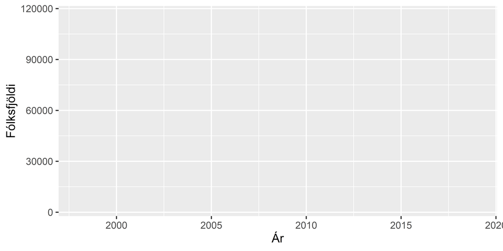

```r
pop_tidy %>%
  ggplot(aes(x = Ár, y = Fólksfjöldi, fill = Landssvæði), color = "pink")
```

## geom

Bæta má öðrum liðum við plottið með því `+` virkjanum. Það fyrsta sem er yfirleitt bætt við er *geometry* sem er safn af föllum sem byrja öll á *geom_* og svo er nafninu á viðkomandi *geom* bætt við. Hér hefur verið bætt við *column*.

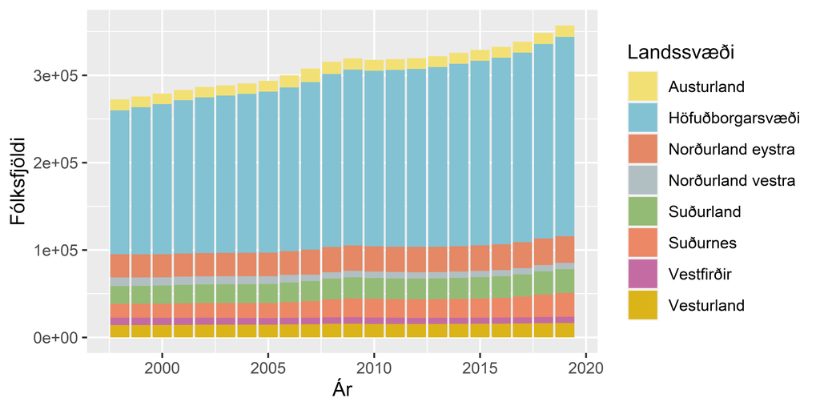

```r
pop_tidy %>%
  ggplot(aes(x = Ár, y = Fólksfjöldi, fill = Landssvæði)) +
  geom_col()
```

Einnig er hægt að setja *mappings* í *geom* föllunum, en það er yfirleitt aðeins gert ef að það á að vera mismunandi eftir *geom*. Í *geom* fallinu má einnig bæta við parametrum sem að eiga að vera óbreytt milli mælinga.

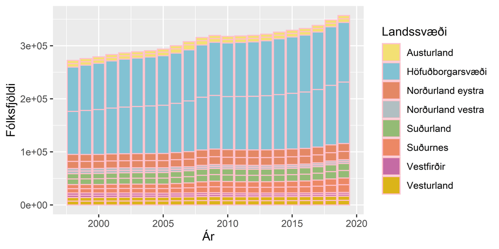

```r
pop_tidy %>%
  ggplot() +
  geom_col(aes(x = Ár, y = Fólksfjöldi, fill = Landssvæði), color = "pink")
```